# When Is the Central Limit Theorem Useful?

A Monte Carlo investigation of five populations

## 1 Executive summary

This investigation compares sampling distributions of means from five populations. Each scenario uses 10,000 independent samples; the sample sizes are 1, 2, 5, 10, 20, 30, 50, 100, 200, 500. The configured seed is 5100, based on the four digits supplied by the student.

There is no universal rule that a sample size of 30 produces a sufficiently normal sampling distribution. Normal population means are exactly normal for every sample size. The die, exponential, and small binomial have finite variance but different degrees of discreteness and skewness, so their normal approximations improve at different rates. Cauchy means remain Cauchy at every sample size.

Provisional numerical screening results. Cauchy screening is inapplicable.

| Population | First tested n passing | First n with all larger passing | n=30 passes | n=30 skewness | n=30 excess kurtosis | n=30 SE ratio |
| --- | --- | --- | --- | --- | --- | --- |
| Standard Normal | 1 | 1 | TRUE | -0.042 | 0.030 | 1.000 |
| Six-Sided Die | 5 | 5 | TRUE | -0.043 | -0.072 | 1.013 |
| Exponential | 100 | 100 | FALSE | 0.398 | 0.318 | 0.999 |
| Binomial Small | 100 | 100 | FALSE | 0.208 | 0.024 | 0.992 |
| Cauchy | NA | NA | NA | NA | NA | NA |

The table reports numerical screening results, which must be interpreted with the plots below. A first passing sample size is a result on this tested grid, rather than an exact minimum or a universal normality threshold. `NA` denotes an undefined or inapplicable quantity, or that no tested size passed.

## 2 Predictions and population assumptions

All generated observations within and between samples are independent. Each population also has identically distributed observations. The ordinary CLT applies to the four populations with finite variance. Cauchy violates the finite-variance assumption; its population mean is also undefined.

Theoretical population properties and predictions specified before simulation.

|  | distribution | theoretical_mean | theoretical_sd | population_skewness | population_excess_kurtosis | prediction |
| --- | --- | --- | --- | --- | --- | --- |
| normal | Standard Normal | 0.0 | 1.000 | 0.000 | 0.000 | Sample means are exactly normal at every n. |
| die | Six-Sided Die | 3.5 | 1.708 | 0.000 | -1.269 | Symmetric but discrete; the normal approximation improves with n. |
| exponential | Exponential | 1.0 | 1.000 | 2.000 | 6.000 | Right skew decreases slowly; mean skewness is 2/sqrt(n). |
| binomial | Binomial Small | 0.5 | 0.671 | 1.193 | 1.022 | Initially skewed and discrete; both effects decrease with n. |
| cauchy | Cauchy | NA | NA | NA | NA | Sample means remain standard Cauchy; the ordinary CLT fails. |

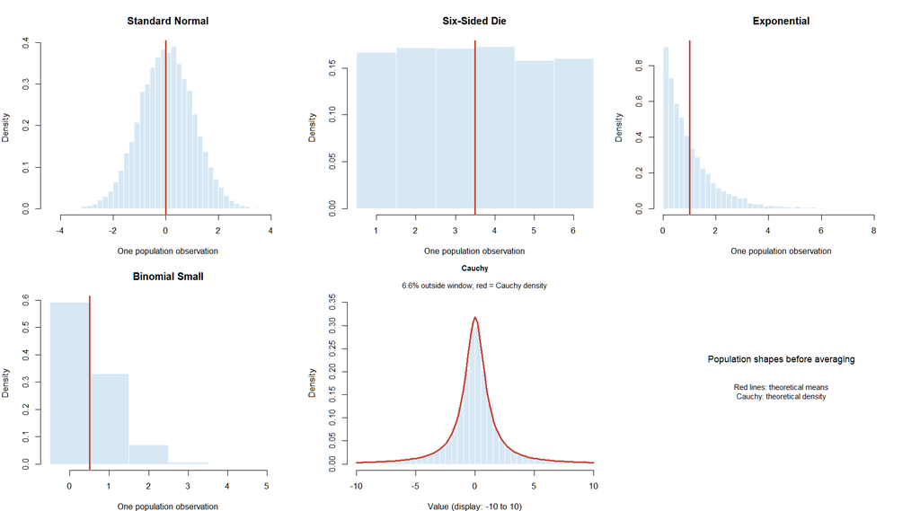

Original population distributions. Cauchy uses a documented display window.

For the small binomial, one population observation counts successes in five trials with success probability 0.10. The simulation’s sample size $n$ counts independent binomial observations; it is separate from the five trials per observation.

## 3 Simulation design and criteria

For each population and each $n$, generate 10000 new independent samples and compute each sample mean. The R code processes samples in batches to limit memory use. A separate deterministic seed for each population and sample size makes existing scenarios reproducible when the grid is expanded.

For finite-variance populations, theory gives

$$E[\bar X]=\mu, \qquad \mathrm{SE}(\bar X)=\frac{\sigma}{\sqrt n}.$$

The empirical SD of the simulated sample means estimates this standard error. The Monte Carlo SE of their simulated average is a different quantity:

$$\mathrm{MCSE}\left(\frac{1}{B}\sum_{b=1}^{B}\bar X_b\right)
=\frac{\sigma}{\sqrt{nB}},$$

where $B$ is the number of simulations. The exported summary includes mean error in units of this MCSE to help distinguish simulation noise from systematic errors.

The provisional numerical screen requires all three conditions:

- Absolute skewness at most 0.2.
- Absolute **excess** kurtosis at most 0.5; normal excess kurtosis is zero.
- Empirical SD divided by theoretical SE within 5% of one.

These are project-specific criteria. SE agreement alone does not establish normality, and the shape estimates themselves contain Monte Carlo noise. Histograms and normal Q-Q plots supply complementary evidence, especially for discreteness, asymmetry, and tail departures. No normality-test p-value determines the conclusion.

An additional diagnostic measures the fraction of sample means inside $\mu \pm 1.96\sigma/\sqrt n$. Approximately normal distributions should give about 95% coverage, but a similar central probability alone does not establish normality. The summary also reports the Monte Carlo SE of this estimated probability.

## 4 Results by population

### 4.1 Standard normal: baseline

Sample means are exactly $N(0,1/n)$ at every $n$. Departures of simulated moments from their theoretical values reflect Monte Carlo noise. This case checks whether the simulation and summaries reproduce known behavior.

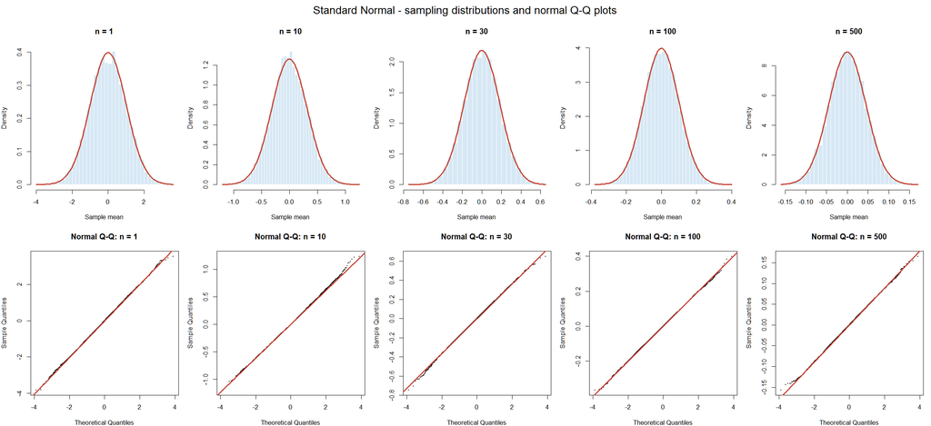

Normal sampling distributions. Red histogram curves show the theoretical normal density.

### 4.2 Six-sided die: symmetric and discrete

The population mean is 3.5 and variance is $35/12$. Small-sample means occupy a finite lattice, visible as steps in the Q-Q plots. Symmetry makes population skewness zero, but does not make the population normal. Its excess kurtosis is $-222/175$, and the excess kurtosis of its sample means is $(-222/175)/n$.

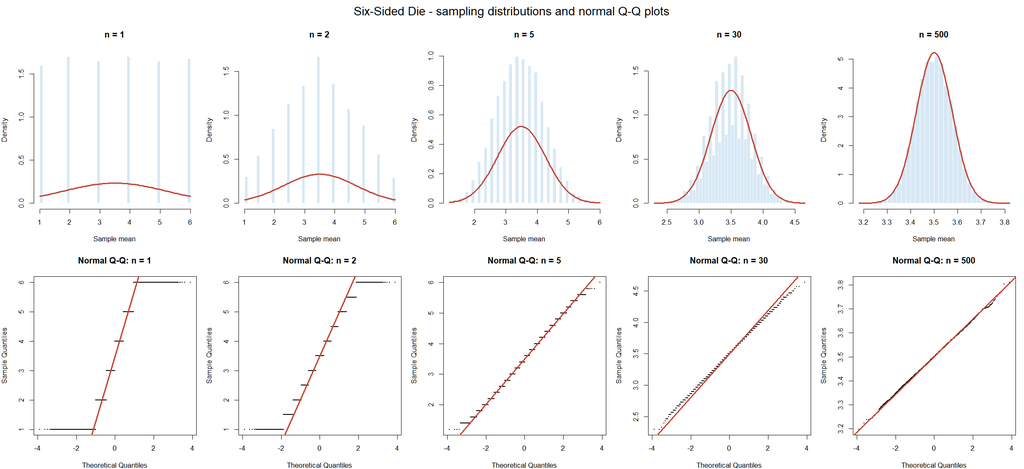

Die sampling distributions and normal Q-Q plots.

### 4.3 Exponential: persistent right skew

The population mean and SD are both one. The skewness of sample means is $2/\sqrt n$ and their excess kurtosis is $6/n$. At $n=30$, theoretical skewness is approximately 0.365, above the chosen cutoff of 0.2. The theoretical skewness reaches 0.20 at $n=100$, so Monte Carlo fluctuations can change whether that particular scenario passes the screen.

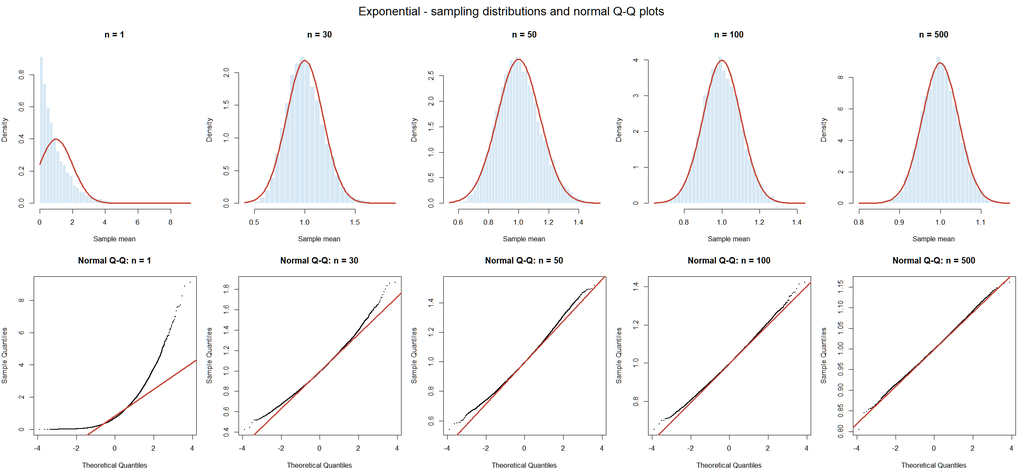

Exponential sampling distributions and normal Q-Q plots.

### 4.4 Small binomial: skewness and discreteness

The population mean is 0.5 and variance is 0.45. The sum of $n$ such independent observations is exactly $\operatorname{Binomial}(5n,0.10)$, and dividing this sum by $n$ gives the sample mean. Its skewness is $(0.8/\sqrt{0.45})/\sqrt n$ and excess kurtosis is $[(1-6(0.1)(0.9))/0.45]/n$. At $n=30$, theoretical skewness is about 0.218. Inspect both tail curvature and the remaining lattice pattern when judging the approximation.

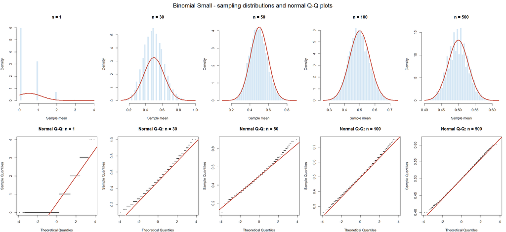

Binomial sampling distributions and normal Q-Q plots.

### 4.5 Cauchy: why the assumptions matter

For independent standard Cauchy observations, the sample mean has the same standard Cauchy distribution for every $n$. Its theoretical median is zero and IQR is two; its spread does not decrease as $1/\sqrt n$. Its mean and variance are undefined, so the ordinary CLT and usual theoretical SE formula do not apply.

Finite simulated means and SDs can be computed, but they are only descriptions of these particular runs. They do not estimate finite population moments. Cauchy skewness, kurtosis, theoretical SE, and normal coverage are deliberately marked `NA` in the summaries.

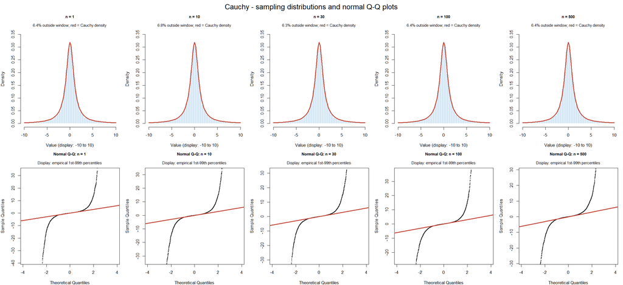

Cauchy sampling distributions. Red curves are Cauchy densities. Histograms show -10 to 10; Q-Q displays show empirical 1st through 99th percentiles. All observations remain in the summaries.

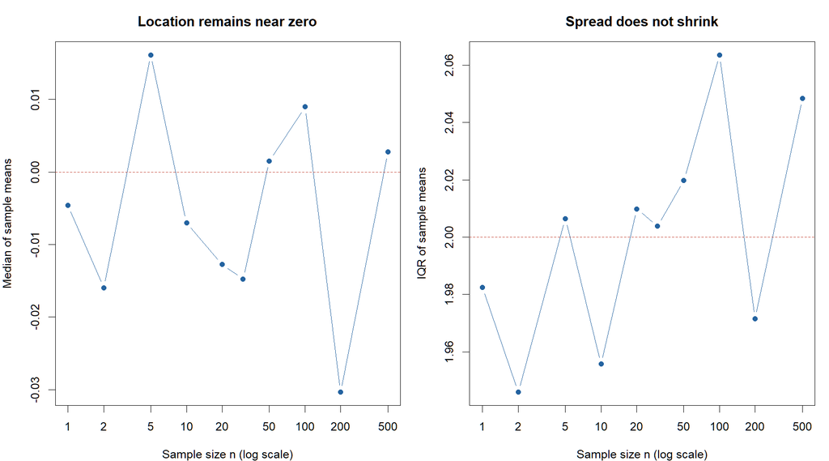

Cauchy medians and IQRs across sample sizes. Red reference lines show the exact values zero and two.

## 5 Comparison with theory

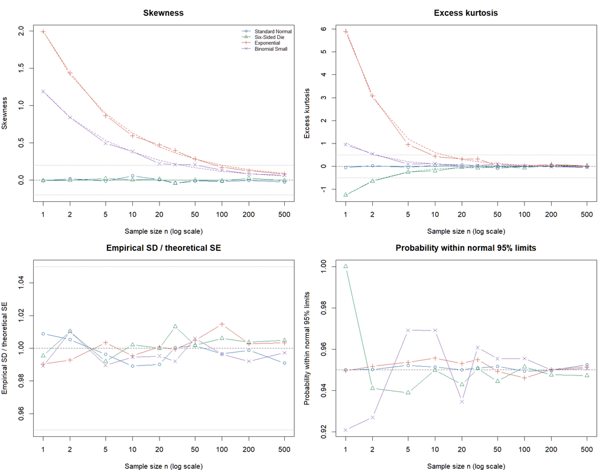

Finite-variance diagnostics. Solid colored lines are simulated values; dashed colored lines in the shape panels are theoretical predictions. Dotted gray lines mark numerical tolerances.

The full table compares simulated means and SDs with theory, shape estimates with their exact predictions, and normal-window coverage with 0.95. Large moment departures should be interpreted together with the plots and Monte Carlo error.

All simulated scenarios; Cauchy mean and SD are descriptive only.

| distribution | n | simulated_mean | theoretical_mean | empirical_sd | theoretical_se | mean_error_in_mc_se | skewness | theoretical_skewness | excess_kurtosis | theoretical_excess_kurtosis | normal_95_coverage | numeric_screen_pass |
| --- | --- | --- | --- | --- | --- | --- | --- | --- | --- | --- | --- | --- |
| Standard Normal | 1 | -0.014 | 0.0 | 1.009 | 1.000 | -1.428 | -0.009 | 0.000 | -0.065 | 0.000 | 0.950 | TRUE |
| Standard Normal | 2 | 0.000 | 0.0 | 0.711 | 0.707 | -0.010 | 0.019 | 0.000 | 0.019 | 0.000 | 0.950 | TRUE |
| Standard Normal | 5 | -0.006 | 0.0 | 0.446 | 0.447 | -1.280 | -0.013 | 0.000 | -0.047 | 0.000 | 0.952 | TRUE |
| Standard Normal | 10 | 0.000 | 0.0 | 0.313 | 0.316 | -0.040 | 0.058 | 0.000 | 0.035 | 0.000 | 0.951 | TRUE |
| Standard Normal | 20 | -0.001 | 0.0 | 0.221 | 0.224 | -0.333 | 0.004 | 0.000 | 0.061 | 0.000 | 0.950 | TRUE |
| Standard Normal | 30 | -0.001 | 0.0 | 0.183 | 0.183 | -0.582 | -0.042 | 0.000 | 0.030 | 0.000 | 0.951 | TRUE |
| Standard Normal | 50 | -0.001 | 0.0 | 0.142 | 0.141 | -0.990 | -0.015 | 0.000 | -0.091 | 0.000 | 0.952 | TRUE |
| Standard Normal | 100 | -0.002 | 0.0 | 0.100 | 0.100 | -1.733 | -0.017 | 0.000 | -0.008 | 0.000 | 0.949 | TRUE |
| Standard Normal | 200 | 0.000 | 0.0 | 0.071 | 0.071 | 0.443 | -0.006 | 0.000 | 0.006 | 0.000 | 0.950 | TRUE |
| Standard Normal | 500 | 0.000 | 0.0 | 0.044 | 0.045 | -0.136 | -0.027 | 0.000 | -0.032 | 0.000 | 0.953 | TRUE |
| Six-Sided Die | 1 | 3.515 | 3.5 | 1.700 | 1.708 | 0.896 | -0.004 | 0.000 | -1.259 | -1.269 | 1.000 | FALSE |
| Six-Sided Die | 2 | 3.499 | 3.5 | 1.220 | 1.208 | -0.099 | -0.002 | 0.000 | -0.660 | -0.634 | 0.941 | FALSE |
| Six-Sided Die | 5 | 3.490 | 3.5 | 0.758 | 0.764 | -1.270 | 0.022 | 0.000 | -0.254 | -0.254 | 0.939 | TRUE |
| Six-Sided Die | 10 | 3.502 | 3.5 | 0.541 | 0.540 | 0.441 | 0.004 | 0.000 | -0.206 | -0.127 | 0.950 | TRUE |
| Six-Sided Die | 20 | 3.497 | 3.5 | 0.382 | 0.382 | -0.837 | 0.014 | 0.000 | -0.045 | -0.063 | 0.943 | TRUE |
| Six-Sided Die | 30 | 3.500 | 3.5 | 0.316 | 0.312 | 0.022 | -0.043 | 0.000 | -0.072 | -0.042 | 0.951 | TRUE |
| Six-Sided Die | 50 | 3.503 | 3.5 | 0.242 | 0.242 | 1.048 | -0.001 | 0.000 | -0.022 | -0.025 | 0.945 | TRUE |
| Six-Sided Die | 100 | 3.502 | 3.5 | 0.172 | 0.171 | 1.196 | -0.010 | 0.000 | -0.062 | -0.013 | 0.952 | TRUE |
| Six-Sided Die | 200 | 3.500 | 3.5 | 0.121 | 0.121 | 0.364 | 0.026 | 0.000 | 0.042 | -0.006 | 0.948 | TRUE |
| Six-Sided Die | 500 | 3.500 | 3.5 | 0.077 | 0.076 | 0.550 | -0.007 | 0.000 | 0.018 | -0.003 | 0.947 | TRUE |
| Exponential | 1 | 0.994 | 1.0 | 0.990 | 1.000 | -0.575 | 1.994 | 2.000 | 5.892 | 6.000 | 0.950 | FALSE |
| Exponential | 2 | 0.992 | 1.0 | 0.702 | 0.707 | -1.081 | 1.438 | 1.414 | 3.085 | 3.000 | 0.952 | FALSE |
| Exponential | 5 | 1.000 | 1.0 | 0.449 | 0.447 | -0.060 | 0.866 | 0.894 | 0.945 | 1.200 | 0.954 | FALSE |
| Exponential | 10 | 1.008 | 1.0 | 0.315 | 0.316 | 2.591 | 0.595 | 0.632 | 0.431 | 0.600 | 0.956 | FALSE |
| Exponential | 20 | 1.000 | 1.0 | 0.224 | 0.224 | -0.037 | 0.473 | 0.447 | 0.314 | 0.300 | 0.953 | FALSE |
| Exponential | 30 | 1.000 | 1.0 | 0.182 | 0.183 | -0.191 | 0.398 | 0.365 | 0.318 | 0.200 | 0.955 | FALSE |
| Exponential | 50 | 1.001 | 1.0 | 0.142 | 0.141 | 0.647 | 0.284 | 0.283 | 0.024 | 0.120 | 0.949 | FALSE |
| Exponential | 100 | 0.999 | 1.0 | 0.101 | 0.100 | -0.682 | 0.173 | 0.200 | 0.014 | 0.060 | 0.946 | TRUE |
| Exponential | 200 | 1.000 | 1.0 | 0.071 | 0.071 | 0.668 | 0.125 | 0.141 | 0.083 | 0.030 | 0.950 | TRUE |
| Exponential | 500 | 1.000 | 1.0 | 0.045 | 0.045 | -0.861 | 0.082 | 0.089 | 0.013 | 0.012 | 0.951 | TRUE |
| Binomial Small | 1 | 0.490 | 0.5 | 0.664 | 0.671 | -1.565 | 1.191 | 1.193 | 0.941 | 1.022 | 0.921 | FALSE |
| Binomial Small | 2 | 0.506 | 0.5 | 0.479 | 0.474 | 1.254 | 0.842 | 0.843 | 0.548 | 0.511 | 0.927 | FALSE |
| Binomial Small | 5 | 0.497 | 0.5 | 0.297 | 0.300 | -0.867 | 0.494 | 0.533 | 0.090 | 0.204 | 0.969 | FALSE |
| Binomial Small | 10 | 0.497 | 0.5 | 0.211 | 0.212 | -1.329 | 0.383 | 0.377 | 0.123 | 0.102 | 0.969 | FALSE |
| Binomial Small | 20 | 0.499 | 0.5 | 0.149 | 0.150 | -0.423 | 0.221 | 0.267 | -0.019 | 0.051 | 0.935 | FALSE |
| Binomial Small | 30 | 0.499 | 0.5 | 0.122 | 0.122 | -0.963 | 0.208 | 0.218 | 0.024 | 0.034 | 0.961 | FALSE |
| Binomial Small | 50 | 0.500 | 0.5 | 0.095 | 0.095 | 0.386 | 0.207 | 0.169 | 0.105 | 0.020 | 0.955 | FALSE |
| Binomial Small | 100 | 0.500 | 0.5 | 0.067 | 0.067 | -0.383 | 0.132 | 0.119 | 0.014 | 0.010 | 0.956 | TRUE |
| Binomial Small | 200 | 0.500 | 0.5 | 0.047 | 0.047 | 0.833 | 0.082 | 0.084 | -0.030 | 0.005 | 0.950 | TRUE |
| Binomial Small | 500 | 0.500 | 0.5 | 0.030 | 0.030 | 0.016 | 0.068 | 0.053 | -0.057 | 0.002 | 0.951 | TRUE |
| Cauchy | 1 | 1.057 | NA | 285.635 | NA | NA | NA | NA | NA | NA | NA | FALSE |
| Cauchy | 2 | -1.429 | NA | 92.240 | NA | NA | NA | NA | NA | NA | NA | FALSE |
| Cauchy | 5 | 1.500 | NA | 124.906 | NA | NA | NA | NA | NA | NA | NA | FALSE |
| Cauchy | 10 | -0.018 | NA | 40.199 | NA | NA | NA | NA | NA | NA | NA | FALSE |
| Cauchy | 20 | 0.866 | NA | 74.253 | NA | NA | NA | NA | NA | NA | NA | FALSE |
| Cauchy | 30 | 0.316 | NA | 36.349 | NA | NA | NA | NA | NA | NA | NA | FALSE |
| Cauchy | 50 | -0.310 | NA | 34.405 | NA | NA | NA | NA | NA | NA | NA | FALSE |
| Cauchy | 100 | 3.599 | NA | 154.369 | NA | NA | NA | NA | NA | NA | NA | FALSE |
| Cauchy | 200 | -0.863 | NA | 176.932 | NA | NA | NA | NA | NA | NA | NA | FALSE |
| Cauchy | 500 | 0.914 | NA | 119.937 | NA | NA | NA | NA | NA | NA | NA | FALSE |

## 6 Limitations and conclusions

The first passing size depends on the chosen thresholds, the tested grid, and simulation noise. A histogram can obscure discreteness through binning, while a Q-Q plot may reveal tail departures even when numerical criteria pass. The Cauchy display windows make the central shape readable, but hide the most extreme points from the display; their presence is explicitly documented and they are retained in all computations. Optional dependent, non-identical, and mixture examples are outside this five-population investigation.

The normal population provides an exact baseline; the die and binomial demonstrate the role of discreteness; exponential data demonstrate gradual reduction of skewness; and Cauchy demonstrates failure of the finite-variance assumption. The appropriate sample size depends on the population and on the accuracy needed for the intended use of the normal approximation.

## 7 Reproducing the analysis

From the repository root, run `source("Project1/project1.R")` in R to generate the tables, plots, and text executive summary. Alternatively use `Rscript Project1/project1.R`. Render this report with `quarto render Project1/project1_report.qmd`.

The simulation uses only base R; rendering requires Quarto, knitr, and rmarkdown. Run settings and R session information are saved in `results/analysis_settings.txt` and `results/session_info.txt`. AI prompts and validation are documented separately in `ai_prompt_log.txt`. Review the figures and explanations before submission.